# Pruebas de Correlación

MSc. Darío Alvarado

Las **pruebas de correlación** sirven para determinar la tendencia, comportamiento o relación que hay entre dos variables cuando están juntas. Su objetivo es determinar si existe una relación entre ellas y en qué dirección (positiva o negativa), es decir, si esa relación es directa o inversamente proporcional. Además, mediante las pruebas de correlación se determina si la relación entre las variables es estadísticamente significativa o no.

#### Paquetes

```r
library(rio)
library(tidyverse)
library(GGally)
library(correlation)
library(see)
library(inspectdf)
```

### Contenido

#### Datos

```r
suelos <- import("data/suelos.xlsx")
head(suelos)
```

```
##   Group Contour Depth Gp Block   pH     N Dens   P    Ca   Mg    K   Na Conduc
## 1     1     Top  0-10 T0     1 5.40 0.188 0.92 215 16.35 7.65 0.72 1.14   1.09
## 2     1     Top  0-10 T0     2 5.65 0.165 1.04 208 12.25 5.15 0.71 0.94   1.35
## 3     1     Top  0-10 T0     3 5.14 0.260 0.95 300 13.02 5.68 0.68 0.60   1.41
## 4     1     Top  0-10 T0     4 5.14 0.169 1.10 248 11.92 7.88 1.09 1.01   1.64
## 5     2     Top 10-30 T1     1 5.14 0.164 1.12 174 14.17 8.12 0.70 2.17   1.85
## 6     2     Top 10-30 T1     2 5.10 0.094 1.22 129  8.55 6.92 0.81 2.67   3.18
```

Podemos explorar gráficamente si dos variables de nuestra tabla de datos están correlacionadas o no.

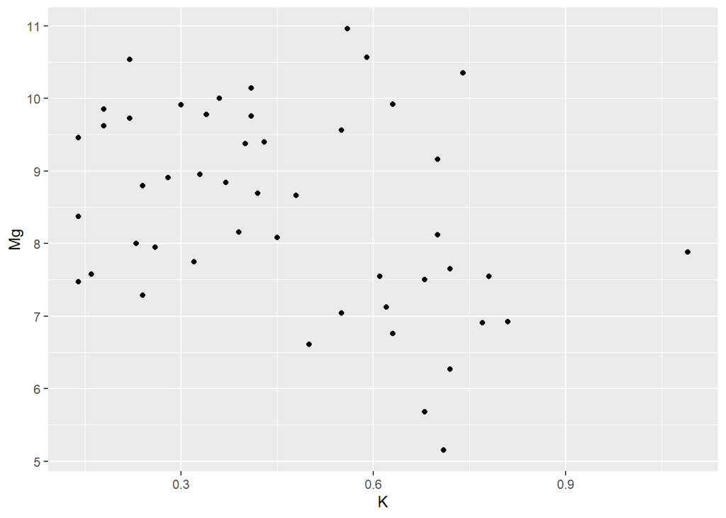

```r
ggplot(suelos, aes(K, Mg)) +
  geom_point()
```

Con un gráfico de dispersión podemos ver si existe un patrón entre las dos variables, por ejemplo, en este gráfico se puede apreciar que no hay un patrón de relación específico entre el potasio (K) y el magnesio (Mg) según los datos de la tabla `suelos`.

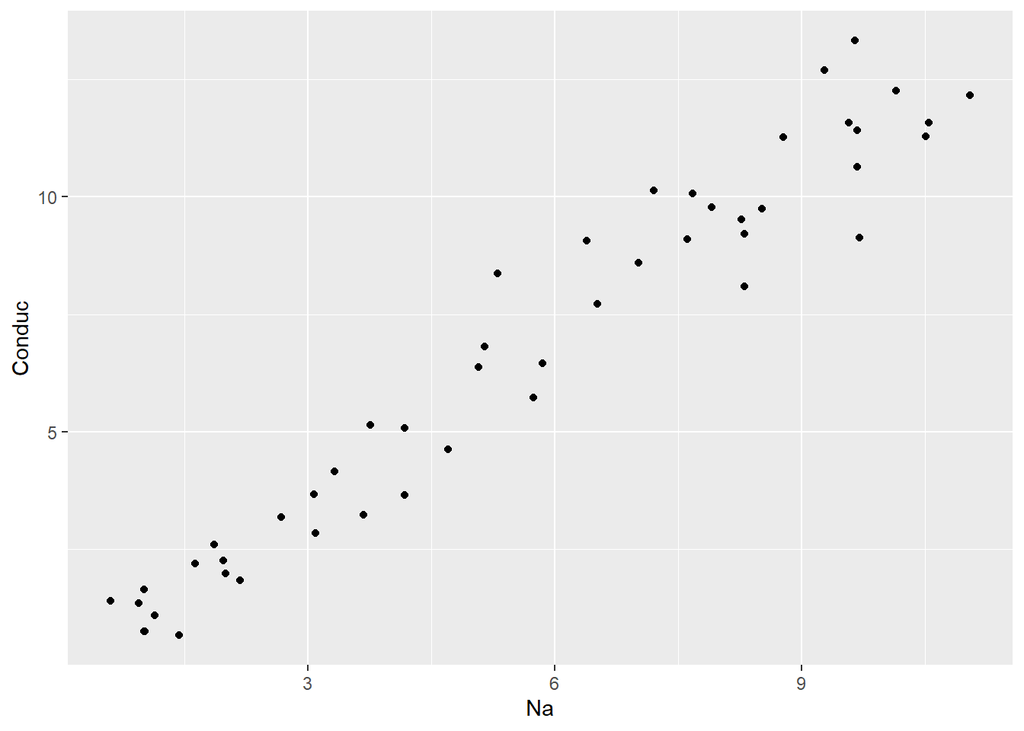

```r
ggplot(suelos, aes(Na, Conduc)) +
  geom_point()
```

En este gráfico se puede apreciar un patrón claro de la relación entre las variables, a mayores concentraciones de sodio (Na) hay mayor conductividad (Conduc) según los datos de la tabla `suelos`.

Pero si queremos obtener un valor numérico de esa relación debemos utilizar pruebas de correlación.

Volver arriba

Inicio

#### Prueba de correlación de Pearson

La **prueba de correlación de Pearson** es un **método paramétrico** para determinar la correlación entre dos variables.

Para utilizar la correlación de Pearson, nuestros datos deben cumplir el supuesto de normalidad.

```r
shapiro.test(suelos$K)
```

```
##
##  Shapiro-Wilk normality test
##
## data:  suelos$K
## W = 0.95276, p-value = 0.05157
```

```r
shapiro.test(suelos$Mg)
```

```
##
##  Shapiro-Wilk normality test
##
## data:  suelos$Mg
## W = 0.97575, p-value = 0.4162
```

Una vez confirmada la normalidad de las dos variables, se ejecuta la función `cor.test()` del paquete base de R:

```r
cor.test(suelos$K, suelos$Mg) # Aquí no importa el orden en el que coloquemos las variables.
```

```
##
##  Pearson's product-moment correlation
##
## data:  suelos$K and suelos$Mg
## t = -2.5898, df = 46, p-value = 0.01282
## alternative hypothesis: true correlation is not equal to 0
## 95 percent confidence interval:
##  -0.5818762 -0.0807700
## sample estimates:
##        cor
## -0.3567182
```

El valor de p indica la significancia estadística de la correlación entre las dos variables.

- Si el valor de **p < 0.05**, La correlación entre las variables es estadísticamente significativa.
- Si el valor de **p ≥ 0.05**, La correlación entre las variables NO es estadísticamente significativa.

El valor de **cor** indica la magnitud y dirección de la correlación, ya que la correlación puede ser positiva o negativa. En este caso, las variables de K y Mg están negativamente correlacionadas (cor = -0.36). Los valores de cor pueden ir de -1 a 1, entre más cercano a -1 o a 1 sea el valor de cor, más fuerte es la correlación entre las variables, entre más cercano a 0 la correlación es más débil.

El intervalo de confianza al 95% nos indica que la verdadera correlación entre las variables podría estar entre -0.58 y -0.08.

*Nota: La correlación de Pearson es una medida de la dependencia lineal entre las dos variables. **Si la relación de una variable con la otra no es lineal, la correlación será baja.***

Volver arriba

Inicio

#### Prueba de correlación de Spearman

Si una de las variables no cumple con el supuesto de normalidad, se puede utilizar una **prueba no paramétrica**, la prueba de **correlación de Spearman**.

```r
shapiro.test(suelos$Na)
```

```
##
##  Shapiro-Wilk normality test
##
## data:  suelos$Na
## W = 0.92795, p-value = 0.005736
```

```r
shapiro.test(suelos$Conduc)
```

```
##
##  Shapiro-Wilk normality test
##
## data:  suelos$Conduc
## W = 0.92367, p-value = 0.004016
```

Para la prueba de Spearman se utiliza la misma función `cor.test()`, pero se especifica el `method = "spearman"`:

```r
cor.test(suelos$Na, suelos$Conduc, method = "spearman")
```

```
##
##  Spearman's rank correlation rho
##
## data:  suelos$Na and suelos$Conduc
## S = 737.6, p-value < 2.2e-16
## alternative hypothesis: true rho is not equal to 0
## sample estimates:
##       rho
## 0.9599653
```

En este caso, el valor de **rho** indica la magnitud y dirección de la correlación (equivalente al valor de **cor** en la prueba de Pearson). En este ejemplo hay una correlación positiva muy fuerte entre las variables Na y Conduc (0.96).

La prueba de Spearman es menos robusta que la de Pearson porque no es específica para un tipo de distribución de los datos. También podemos aplicar la prueba de Pearson si los datos no cumplen el supuesto de normalidad, aunque esta pierde un poco de robustez.

Volver arriba

Inicio

#### Prueba de correlación de Kendall

Otra alternativa **no paramétrica** es la **prueba de correlación de Kendall**:

```r
cor.test(suelos$Na, suelos$Conduc, method = "kendall")
```

```
##
##  Kendall's rank correlation tau
##
## data:  suelos$Na and suelos$Conduc
## z = 8.2586, p-value < 2.2e-16
## alternative hypothesis: true tau is not equal to 0
## sample estimates:
##       tau
## 0.8254117
```

En este caso, el valor de **tau** indica la magnitud y dirección de la correlación.

Volver arriba

Inicio

#### Matrices de correlación

También podemos evaluar la correlación entre más de dos variables, una contra otra.

Podemos utilizar la función `ggpairs()` del paquete `GGally`. Aunque para esta función debemos seleccionar solo las variables numéricas de nuestra base de datos:

```r
suelosb <- suelos[,6:14] # seleccionamos de la columna 6 a la 14 que son las que contienen las variables numéricas que queremos evaluar
head(suelosb)
```

```
##     pH     N Dens   P    Ca   Mg    K   Na Conduc
## 1 5.40 0.188 0.92 215 16.35 7.65 0.72 1.14   1.09
## 2 5.65 0.165 1.04 208 12.25 5.15 0.71 0.94   1.35
## 3 5.14 0.260 0.95 300 13.02 5.68 0.68 0.60   1.41
## 4 5.14 0.169 1.10 248 11.92 7.88 1.09 1.01   1.64
## 5 5.14 0.164 1.12 174 14.17 8.12 0.70 2.17   1.85
## 6 5.10 0.094 1.22 129  8.55 6.92 0.81 2.67   3.18
```

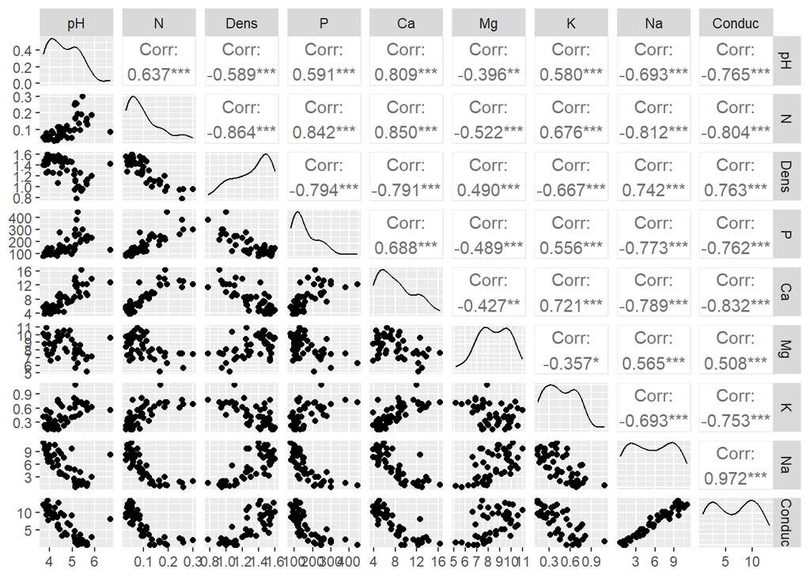

```r
ggpairs(suelosb)
```

El resultado nos muestra una matriz diagonal.

- La diagonal muestra gráficos de densidad con la distribución de cada variable (individualmente).
- Bajo la diagonal se muestran gráficos de dispersión de la relación entre todas las variables (una contra otra).
- Sobre la diagonal se muestran los valores de correlación entre las variables y la significancia estadísitica de la correlación (en simbología).

Para observar más detalladamente podemos seleccionar solo algunas variables de interés:

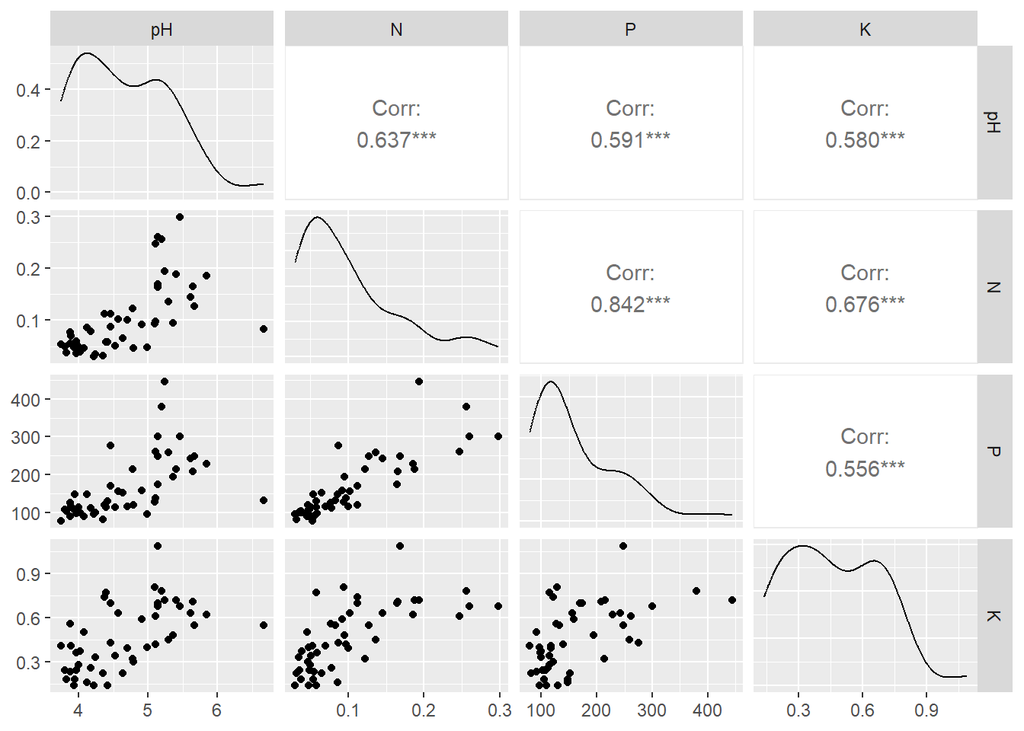

```r
ggpairs(suelosb, c("pH", "N", "P", "K"))
```

Este resultado es compatible con `ggplot2` y podemos guardarlo como imagen:

```r
ggsave("Imagenes/correlacion.jpg")
```

También podemos evaluar la correlación entre las variables con la función `correlation()` del paquete `correlation`. Para esta función no es necesario seleccionar las variables numéricas de nuestra base de datos.

```r
c <- correlation(suelos)
c
```

```
## # Correlation Matrix (pearson-method)
##
## Parameter1 | Parameter2 |     r |         95% CI |  t(46) |         p
## ---------------------------------------------------------------------
## pH         |          N |  0.64 | [ 0.43,  0.78] |   5.60 | < .001***
## pH         |       Dens | -0.59 | [-0.75, -0.37] |  -4.94 | < .001***
## pH         |          P |  0.59 | [ 0.37,  0.75] |   4.97 | < .001***
## pH         |         Ca |  0.81 | [ 0.68,  0.89] |   9.32 | < .001***
## pH         |         Mg | -0.40 | [-0.61, -0.13] |  -2.92 | 0.011*
## pH         |          K |  0.58 | [ 0.35,  0.74] |   4.82 | < .001***
## pH         |         Na | -0.69 | [-0.82, -0.51] |  -6.52 | < .001***
## pH         |     Conduc | -0.76 | [-0.86, -0.61] |  -8.05 | < .001***
## N          |       Dens | -0.86 | [-0.92, -0.77] | -11.65 | < .001***
## N          |          P |  0.84 | [ 0.73,  0.91] |  10.59 | < .001***
## N          |         Ca |  0.85 | [ 0.75,  0.91] |  10.95 | < .001***
## N          |         Mg | -0.52 | [-0.70, -0.28] |  -4.15 | 0.001**
## N          |          K |  0.68 | [ 0.49,  0.81] |   6.22 | < .001***
## N          |         Na | -0.81 | [-0.89, -0.69] |  -9.43 | < .001***
## N          |     Conduc | -0.80 | [-0.89, -0.67] |  -9.16 | < .001***
## Dens       |          P | -0.79 | [-0.88, -0.66] |  -8.85 | < .001***
## Dens       |         Ca | -0.79 | [-0.88, -0.65] |  -8.78 | < .001***
## Dens       |         Mg |  0.49 | [ 0.24,  0.68] |   3.81 | 0.002**
## Dens       |          K | -0.67 | [-0.80, -0.47] |  -6.07 | < .001***
## Dens       |         Na |  0.74 | [ 0.58,  0.85] |   7.51 | < .001***
## Dens       |     Conduc |  0.76 | [ 0.61,  0.86] |   7.99 | < .001***
## P          |         Ca |  0.69 | [ 0.50,  0.81] |   6.42 | < .001***
## P          |         Mg | -0.49 | [-0.68, -0.24] |  -3.80 | 0.002**
## P          |          K |  0.56 | [ 0.32,  0.73] |   4.53 | < .001***
## P          |         Na | -0.77 | [-0.87, -0.63] |  -8.26 | < .001***
## P          |     Conduc | -0.76 | [-0.86, -0.61] |  -7.97 | < .001***
## Ca         |         Mg | -0.43 | [-0.63, -0.16] |  -3.21 | 0.007**
## Ca         |          K |  0.72 | [ 0.55,  0.83] |   7.06 | < .001***
## Ca         |         Na | -0.79 | [-0.88, -0.65] |  -8.71 | < .001***
## Ca         |     Conduc | -0.83 | [-0.90, -0.72] | -10.18 | < .001***
## Mg         |          K | -0.36 | [-0.58, -0.08] |  -2.59 | 0.013*
## Mg         |         Na |  0.56 | [ 0.33,  0.73] |   4.64 | < .001***
## Mg         |     Conduc |  0.51 | [ 0.26,  0.69] |   4.00 | 0.001**
## K          |         Na | -0.69 | [-0.82, -0.51] |  -6.52 | < .001***
## K          |     Conduc | -0.75 | [-0.85, -0.60] |  -7.76 | < .001***
## Na         |     Conduc |  0.97 | [ 0.95,  0.98] |  28.27 | < .001***
##
## p-value adjustment method: Holm (1979)
## Observations: 48
```

Aquí, **r** = correlación de Pearson.

Si el IC95 NO traslapa con el 0, la correlación es significativa.

Podemos exportar este resultado como una tabla de la siguiente manera:

```r
cor <- data.frame(correlation(suelos))
export(cor,"Resultados/correlacionsuelos.xlsx")
```

También podemos graficarlo. Para esto generamos un resumen de las correlaciones entre las variables:

```r
sc <- summary(c) # para generar una matriz de correlación
sc
```

```
## # Correlation Matrix (pearson-method)
##
## Parameter |   Conduc |       Na |        K |      Mg |       Ca |        P
## --------------------------------------------------------------------------
## pH        | -0.76*** | -0.69*** |  0.58*** |  -0.40* |  0.81*** |  0.59***
## N         | -0.80*** | -0.81*** |  0.68*** | -0.52** |  0.85*** |  0.84***
## Dens      |  0.76*** |  0.74*** | -0.67*** |  0.49** | -0.79*** | -0.79***
## P         | -0.76*** | -0.77*** |  0.56*** | -0.49** |  0.69*** |
## Ca        | -0.83*** | -0.79*** |  0.72*** | -0.43** |          |
## Mg        |   0.51** |  0.56*** |   -0.36* |         |          |
## K         | -0.75*** | -0.69*** |          |         |          |
## Na        |  0.97*** |          |          |         |          |
##
## Parameter |     Dens |       N
## ------------------------------
## pH        | -0.59*** | 0.64***
## N         | -0.86*** |
## Dens      |          |
## P         |          |
## Ca        |          |
## Mg        |          |
## K         |          |
## Na        |          |
##
## p-value adjustment method: Holm (1979)
```

Y graficamos con la función `plot()` del paquete `see`.

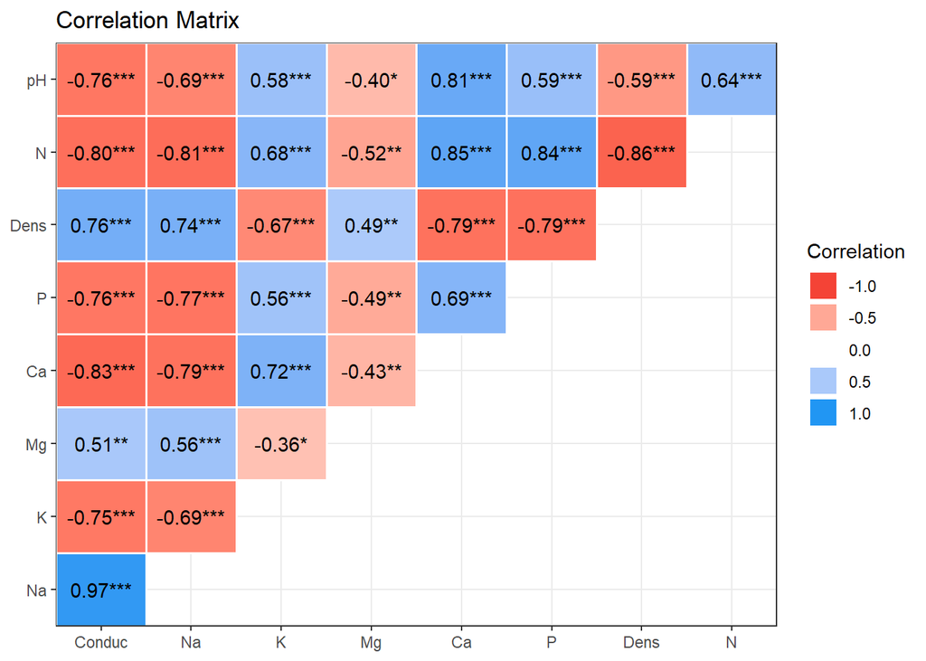

```r
plot(sc) +
  theme_bw()
```

```r
# El resultado nos muestra una matriz de correlación de una forma más gráfica, los colores indican la dirección y la magnitud de la correlación.
```

```r
ggsave("Imagenes/corr.jpg")
```

También podemos especificar el método de la prueba de correlación con el argumento `method =`.

```r
cor_spearman <- correlation(suelos, method = "spearman")
cor_spearman
```

```
## # Correlation Matrix (spearman-method)
##
## Parameter1 | Parameter2 |   rho |         95% CI |        S |         p
## -----------------------------------------------------------------------
## pH         |          N |  0.73 | [ 0.56,  0.84] |  4920.47 | < .001***
## pH         |       Dens | -0.61 | [-0.77, -0.39] | 29653.95 | < .001***
## pH         |          P |  0.75 | [ 0.58,  0.85] |  4698.05 | < .001***
## pH         |         Ca |  0.81 | [ 0.69,  0.89] |  3417.43 | < .001***
## pH         |         Mg | -0.43 | [-0.64, -0.16] | 26330.43 | 0.014*
## pH         |          K |  0.61 | [ 0.39,  0.77] |  7137.57 | < .001***
## pH         |         Na | -0.78 | [-0.87, -0.63] | 32714.15 | < .001***
## pH         |     Conduc | -0.85 | [-0.92, -0.74] | 34110.83 | < .001***
## N          |       Dens | -0.77 | [-0.87, -0.62] | 32642.53 | < .001***
## N          |          P |  0.88 | [ 0.80,  0.94] |  2125.36 | < .001***
## N          |         Ca |  0.86 | [ 0.76,  0.92] |  2612.85 | < .001***
## N          |         Mg | -0.42 | [-0.63, -0.15] | 26158.84 | 0.015*
## N          |          K |  0.74 | [ 0.56,  0.85] |  4874.62 | < .001***
## N          |         Na | -0.88 | [-0.93, -0.78] | 34547.06 | < .001***
## N          |     Conduc | -0.87 | [-0.93, -0.78] | 34520.75 | < .001***
## Dens       |          P | -0.71 | [-0.83, -0.53] | 31505.93 | < .001***
## Dens       |         Ca | -0.76 | [-0.86, -0.60] | 32401.49 | < .001***
## Dens       |         Mg |  0.39 | [ 0.11,  0.61] | 11203.30 | 0.023*
## Dens       |          K | -0.68 | [-0.81, -0.48] | 30870.66 | < .001***
## Dens       |         Na |  0.66 | [ 0.46,  0.80] |  6198.54 | < .001***
## Dens       |     Conduc |  0.71 | [ 0.53,  0.83] |  5309.46 | < .001***
## P          |         Ca |  0.75 | [ 0.58,  0.85] |  4682.28 | < .001***
## P          |         Mg | -0.37 | [-0.60, -0.09] | 25216.40 | 0.030*
## P          |          K |  0.58 | [ 0.35,  0.75] |  7721.24 | < .001***
## P          |         Na | -0.83 | [-0.90, -0.71] | 33734.65 | < .001***
## P          |     Conduc | -0.81 | [-0.89, -0.67] | 33268.74 | < .001***
## Ca         |         Mg | -0.34 | [-0.58, -0.05] | 24694.51 | 0.035*
## Ca         |          K |  0.72 | [ 0.54,  0.84] |  5184.61 | < .001***
## Ca         |         Na | -0.78 | [-0.87, -0.63] | 32806.34 | < .001***
## Ca         |     Conduc | -0.85 | [-0.91, -0.74] | 34082.77 | < .001***
## Mg         |          K | -0.34 | [-0.58, -0.06] | 24729.40 | 0.035*
## Mg         |         Na |  0.54 | [ 0.30,  0.72] |  8439.65 | < .001***
## Mg         |     Conduc |  0.48 | [ 0.22,  0.68] |  9518.52 | 0.004**
## K          |         Na | -0.67 | [-0.81, -0.47] | 30801.71 | < .001***
## K          |     Conduc | -0.75 | [-0.85, -0.58] | 32218.74 | < .001***
## Na         |     Conduc |  0.96 | [ 0.93,  0.98] |   737.60 | < .001***
##
## p-value adjustment method: Holm (1979)
## Observations: 48
```

Otra forma de evaluar la correlación entre variables es con la función `inspect_cor()` del paquete `inspectdf`:

```r
ic <- inspect_cor(suelos)
ic
```

```
## # A tibble: 36 × 7
##    col_1  col_2   corr  p_value  lower  upper pcnt_nna
##    <chr>  <chr>  <dbl>    <dbl>  <dbl>  <dbl>    <dbl>
##  1 Conduc Na     0.972 6.89e-11  0.951  0.985      100
##  2 Dens   N     -0.864 6.75e- 9 -0.922 -0.769      100
##  3 Ca     N      0.850 1.17e- 8  0.746  0.914      100
##  4 P      N      0.842 1.61e- 8  0.734  0.909      100
##  5 Conduc Ca    -0.832 2.38e- 8 -0.903 -0.718      100
##  6 Na     N     -0.812 5.13e- 8 -0.891 -0.686      100
##  7 Ca     pH     0.809 5.81e- 8  0.681  0.889      100
##  8 Conduc N     -0.804 6.97e- 8 -0.886 -0.673      100
##  9 P      Dens  -0.794 1.01e- 7 -0.879 -0.658      100
## 10 Ca     Dens  -0.791 1.10e- 7 -0.878 -0.654      100
## # ℹ 26 more rows
```

Y esto también podemos graficarlo incluyendo los intervalos de confianza al 95% con la función `show_plot()` del paquete `inspectdf`:

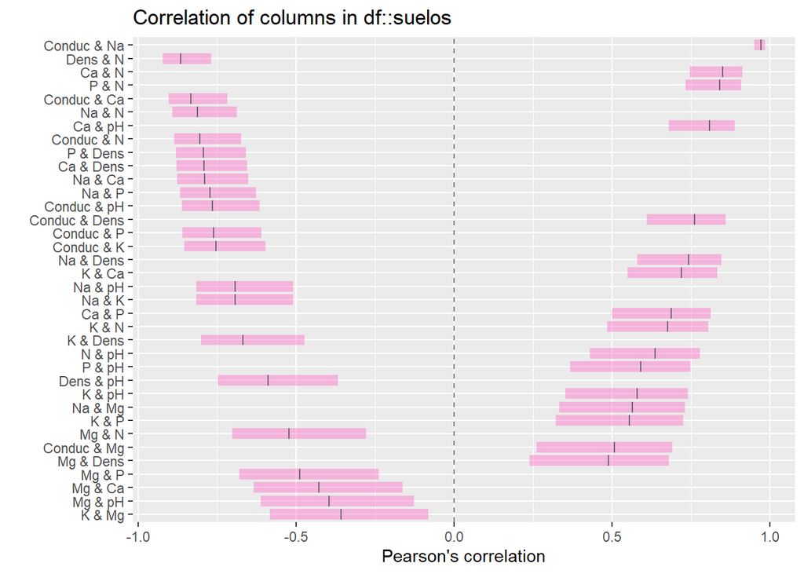

```r
cor_suelos <- show_plot(ic)
cor_suelos
```

```r
# Como se puede observar, todas las correlaciones de esta base de datos son significativas, ya que ningún intervalo de confianza traslapa con el 0.
```

```r
ggsave("Imagenes/cor_suelos.jpg")
```

Un ejemplo con correlaciones no significativas:

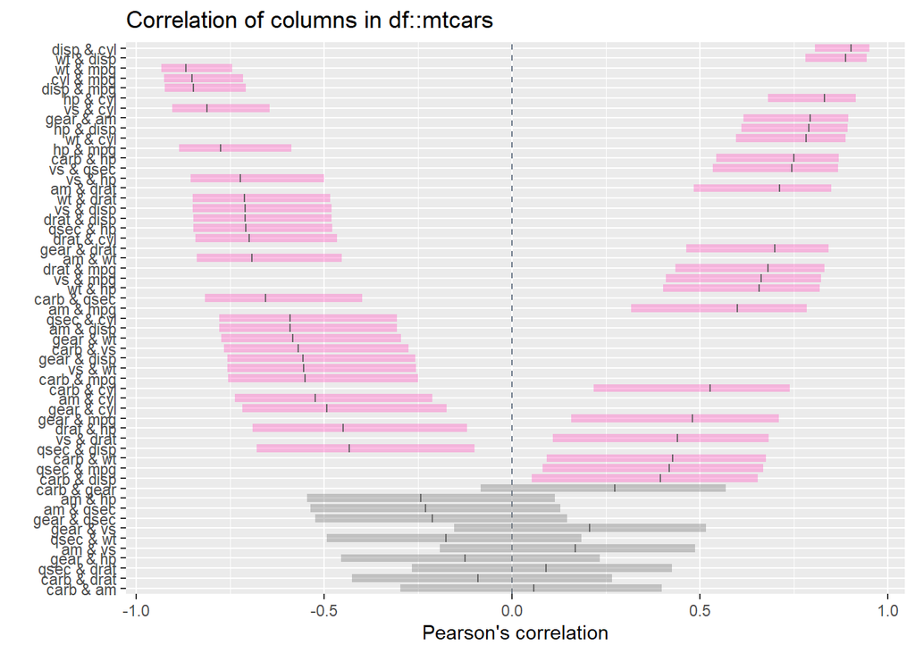

```r
cor_mtcars <- inspect_cor(mtcars) # "mtcars" es una base de datos del paquete base de R que contiene datos de pruebas en carretera de diferentes motores de automóviles.

show_plot(cor_mtcars)
```

Volver arriba

Inicio